# Une analyse qui sent bon ! ou text-mining des ingrédients dans les parfums (1)

Kezhan SHI

31 mai 2016

# 1 Introduction

“Il y a un nouveau Musée du Parfum à Paris, il a l’air trop bien !” Ainsi, je l’ai accompagnée pour découvrir ce musée niché au coeur de la capitale, et j’ai appris qu’un parfum, comme un morceau de musique, est composé de plusieurs notes, qui représentent les différentes senteurs.

- Notes de tête : constituées de matières premières les plus légères, les plus volatiles, qui vont ressortir dés le départ de l’application.
- Notes de coeur : molécules à volatilité moyenne et elles ont un rôle tampon, prolonger la fraîcheur des notes de tête, et annoncer la chaleur des notes de fond.
- Notes de fond : molécules les plus lourdes constituent les notes de fond, et elles donnent de la personnalité au parfum.

Je ne suis pas un nez, j’étais incapable de reconnaître l’origine des senteurs dans les parfums. Mais je sais analyser les données…

# 2 Préparation des données

## 2.1 Sources des données

La base de données contiennent uniquement deux variables : les noms des parfums, et leurs descriptions. Il se peut que les notes des parfums soient précisées : notes de tête, notes de coeur et notes de fond.

L’analyse portera uniquement sur ces données textuelles, et ne contitue pas une analyse quantitative.

```r
head(data,4)
```

```
##                            noms
## 1:           dolce floral drops
## 2:                      illicit
## 3: la vie est belle eau florale
## 4:             la vie est belle
##                                                                                                                                                                                                                                                                                                          …
## 1:                                                                                                                                                                                                                                                                                                       …
## 2:                                     vif et provocant mais doté dune douceur sous-jacente, illicit est un floriental moderne à la signature envoûtante et naturellement féminine.une expérience olfactive totalement unique, où les nuances réconfortantes du gingembre flirtent avec les notes féminin…
## 3:                                                                                                                                                                                                                                                                                                       …
## 4: embellissez votre vie avec la vie est belle, le féminin iconique de lancôme. incarnée par julia roberts, la vie est belle est une ode universelle à la beauté de la vie. une signature unique créée par trois des plus grands eurs français. une déclaration olfactive unique, créée par trois des plu…
```

# 3 Analyse globale des ingrédients

Dans un premier temps, je voulais analyser les mots les plus fréquemment utilisés dans ces descriptions. Puis, un nettoyage des mots vides nous donnera des informations sur les principaux ingrédients utilisé dans les parfums.

## 3.1 Extraction des ingrédients

```r
corpus = Corpus(VectorSource(data$notes))
corpus <- tm_map(corpus, removePunctuation)
corpus= tm_map(corpus, stemDocument)
mots_vides=read.csv2("mots_vides.csv")$ingredients
corpus = tm_map(corpus, removeWords, mots_vides)
dtm = DocumentTermMatrix(corpus)

ingredient.counts = apply(dtm, 1, function (x) sum(x))
dtm = dtm[ingredient.counts > 0,]

dtm_m = as.matrix(dtm)

ingredients.frequences = sort(colSums(dtm_m), decreasing=TRUE)
ingredients.frequences = data.frame(ingredients = names(ingredients.frequences),
                                    freq=ingredients.frequences)

ingredients.frequences$ingredients = reorder(ingredients.frequences$ingredients,
                                             ingredients.frequences$freq)
```

## 3.2 Visualisation des principaux ingrédients

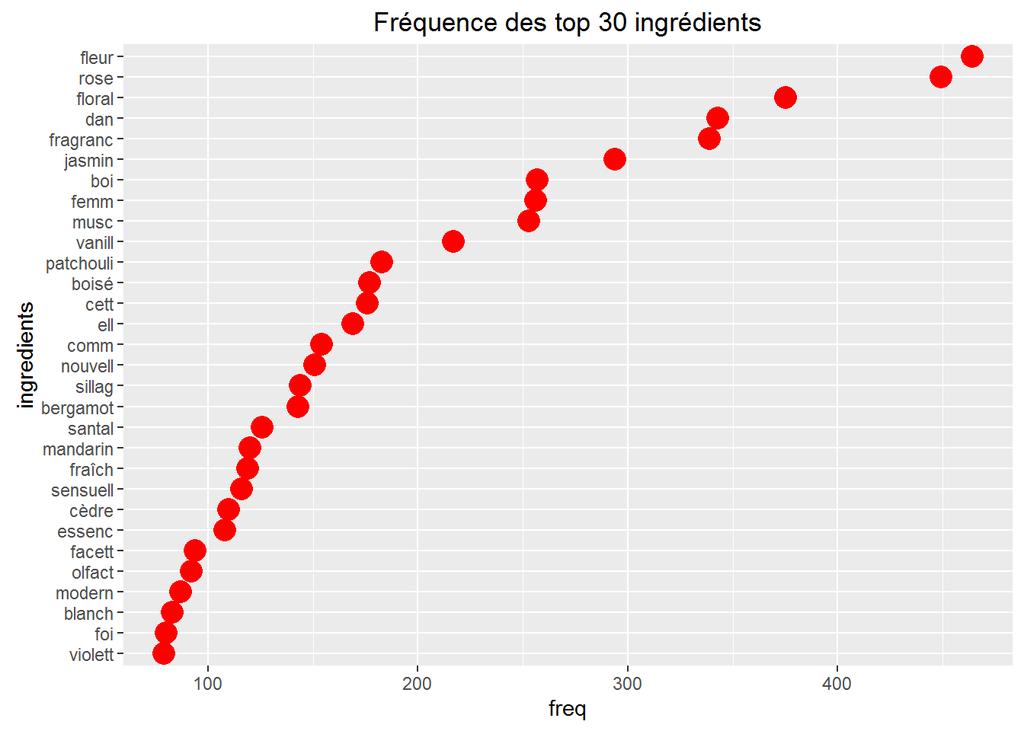

```r
ggplot(ingredients.frequences[1:30,], aes(x=ingredients, y=freq)) +
  geom_point(size=5, colour="red") + coord_flip() +
  ggtitle("Fréquence des top 30 ingrédients")
```

# 4 Modélisation des topics

```r
corpus2 = tm_map(corpus, removeWords, c(as.character(mots_vides),"fleur","floral","rose"))
dtm2 = DocumentTermMatrix(corpus2)
ingredient.counts2 = apply(dtm2, 1, function (x) sum(x))
dtm2 = dtm2[ingredient.counts2 > 0,]
recipes.lda = LDA(dtm2, 7)
t = terms(recipes.lda,6)
t
```

```
##      Topic 1    Topic 2     Topic 3    Topic 4    Topic 5    Topic 6
## [1,] "dan"      "femm"      "boi"      "boi"      "femm"     "vanill"
## [2,] "jasmin"   "dan"       "jasmin"   "fragranc" "fragranc" "comm"
## [3,] "mandarin" "boi"       "dan"      "cett"     "jasmin"   "dan"
## [4,] "ell"      "patchouli" "musc"     "musc"     "dan"      "fragranc"
## [5,] "tonka"    "fragranc"  "fragranc" "jasmin"   "vanill"   "jasmin"
## [6,] "bergamot" "boisé"     "nouvell"  "dan"      "musc"     "musc"
##      Topic 7
## [1,] "fragranc"
## [2,] "dan"
## [3,] "musc"
## [4,] "femm"
## [5,] "ell"
## [6,] "boi"
```

# 5 A continuer

Cette analyse globale permet de voir les notes de manière confondues. Il est sans doute intéressant de voir l’association de différentes notes.

Copyright © 2016 Blog de Kezhan Shi